# Final Project: Recommendation Systems

Shyni David

6/6/2019

#### Using the movielens data as in (1), limit yourself to **movies from the years 2000 to 2016**.

#### 1. Explore the data, and propose a system to bucketize the ratings on the Low-high scale (0-1). For instance, you may consider a way to deal with individual-level anchoring levels as you have see in other classes. Provide descriptive evidence of the variability in ratings.

#### 2. Create a testing and a training subset. I’d suggest leaving 10% out

#### 3. Build (and tune, see (1)) a recommendation system using both User-Based and Item-Based CF algorithms with different similarity measures (cosine vs. Pearson etc) and providing recommendation for the top 7 movies.

#### 4. Evaluate the performance of both algorithms in the testing set.

A collaborative filtering recommender (CFR) system is being used where filtering approach is based only on user preferences rather than movie features or contents. If two users share the same interests in the past then the recommender predicts similar taste in future.

Load Libraries

```r
setwd("~/Desktop/FISHER SMB-A/Term 5/Macro Marketing/Recommendation Systems/Recommendation System Final Project")
library(readr)
library(tidyverse)
library(sqldf)
library(scales)
#install.packages("recommenderlab")
library(recommenderlab)
library(caret)
library(data.table)
```

Load Dataset

```r
movies <- read_csv("movies.csv")
ratings <- read_csv("movieRec-master/ratings.csv", col_types = cols(timestamp = col_double()))
search <- read_csv("movieRec-master/search.csv")
```

Analysing Data

```r
glimpse(movies)
```

```
## Observations: 10,329
## Variables: 3
## $ movieId <dbl> 1, 2, 3, 4, 5, 6, 7, 8, 9, 10, 11, 12, 13, 14, 15, 16, 1…
## $ title   <chr> "Toy Story (1995)", "Jumanji (1995)", "Grumpier Old Men …
## $ genres  <chr> "Adventure|Animation|Children|Comedy|Fantasy", "Adventur…
```

```r
glimpse(ratings)
```

```
## Observations: 105,339
## Variables: 4
## $ userId    <dbl> 1, 1, 1, 1, 1, 1, 1, 1, 1, 1, 1, 1, 1, 1, 1, 1, 1, 1, …
## $ movieId   <dbl> 16, 24, 32, 47, 50, 110, 150, 161, 165, 204, 223, 256,…
## $ rating    <dbl> 4.0, 1.5, 4.0, 4.0, 4.0, 4.0, 3.0, 4.0, 3.0, 0.5, 4.0,…
## $ timestamp <dbl> 1217897793, 1217895807, 1217896246, 1217896556, 121789…
```

```r
glimpse(search)
```

```
## Observations: 10,329
## Variables: 21
## $ movieId     <dbl> 1, 2, 3, 4, 5, 6, 7, 8, 9, 10, 11, 12, 13, 14, 15, 1…
## $ title       <chr> "Toy Story (1995)", "Jumanji (1995)", "Grumpier Old …
## $ year        <dbl> 1995, 1995, 1995, 1995, 1995, 1995, 1995, 1995, 1995…
## $ Action      <dbl> 0, 0, 0, 0, 0, 1, 0, 0, 1, 1, 0, 0, 0, 0, 1, 0, 0, 0…
## $ Adventure   <dbl> 1, 1, 0, 0, 0, 0, 0, 1, 0, 1, 0, 0, 1, 0, 1, 0, 0, 0…
## $ Animation   <dbl> 1, 0, 0, 0, 0, 0, 0, 0, 0, 0, 0, 0, 1, 0, 0, 0, 0, 0…
## $ Children    <dbl> 1, 1, 0, 0, 0, 0, 0, 1, 0, 0, 0, 0, 1, 0, 0, 0, 0, 0…
## $ Comedy      <dbl> 1, 0, 1, 1, 1, 0, 1, 0, 0, 0, 1, 1, 0, 0, 0, 0, 0, 1…
## $ Crime       <dbl> 0, 0, 0, 0, 0, 1, 0, 0, 0, 0, 0, 0, 0, 0, 0, 1, 0, 0…
## $ Documentary <dbl> 0, 0, 0, 0, 0, 0, 0, 0, 0, 0, 0, 0, 0, 0, 0, 0, 0, 0…
## $ Drama       <dbl> 0, 0, 0, 1, 0, 0, 0, 0, 0, 0, 1, 0, 0, 1, 0, 1, 1, 0…
## $ Fantasy     <dbl> 1, 1, 0, 0, 0, 0, 0, 0, 0, 0, 0, 0, 0, 0, 0, 0, 0, 0…
## $ `Film-Noir` <dbl> 0, 0, 0, 0, 0, 0, 0, 0, 0, 0, 0, 0, 0, 0, 0, 0, 0, 0…
## $ Horror      <dbl> 0, 0, 0, 0, 0, 0, 0, 0, 0, 0, 0, 1, 0, 0, 0, 0, 0, 0…
## $ Musical     <dbl> 0, 0, 0, 0, 0, 0, 0, 0, 0, 0, 0, 0, 0, 0, 0, 0, 0, 0…
## $ Mystery     <dbl> 0, 0, 0, 0, 0, 0, 0, 0, 0, 0, 0, 0, 0, 0, 0, 0, 0, 0…
## $ Romance     <dbl> 0, 0, 1, 1, 0, 0, 1, 0, 0, 0, 1, 0, 0, 0, 1, 0, 1, 0…
## $ `Sci-Fi`    <dbl> 0, 0, 0, 0, 0, 0, 0, 0, 0, 0, 0, 0, 0, 0, 0, 0, 0, 0…
## $ Thriller    <dbl> 0, 0, 0, 0, 0, 1, 0, 0, 0, 1, 0, 0, 0, 0, 0, 0, 0, 0…
## $ War         <dbl> 0, 0, 0, 0, 0, 0, 0, 0, 0, 0, 0, 0, 0, 0, 0, 0, 0, 0…
## $ Western     <dbl> 0, 0, 0, 0, 0, 0, 0, 0, 0, 0, 0, 0, 0, 0, 0, 0, 0, 0…
```

#### Data Pre-processing

1. Cleaning movies file The movie file has multiple genres for each movie. We will re-organize the file so that each movie has separate specific genres. This will make comparison more easier based on genre.

```r
glimpse(movies)
```

```
## Observations: 10,329
## Variables: 3
## $ movieId <dbl> 1, 2, 3, 4, 5, 6, 7, 8, 9, 10, 11, 12, 13, 14, 15, 16, 1…
## $ title   <chr> "Toy Story (1995)", "Jumanji (1995)", "Grumpier Old Men …
## $ genres  <chr> "Adventure|Animation|Children|Comedy|Fantasy", "Adventur…
```

```r
movies_01 <- movies %>% separate(genres, c("genre1", "genre2", "genre3", "genre4", "genre5"), sep="\\|")

# Clean Movie file
movies_02 <- movies_01 %>%  extract(title, c("title_mv", "Year"), regex = "^(.*) \\(([0-9 \\-]*)\\)$", remove = FALSE)
summary(movies_02)
```

```
##     movieId          title             title_mv             Year
##  Min.   :     1   Length:10329       Length:10329       Length:10329
##  1st Qu.:  3240   Class :character   Class :character   Class :character
##  Median :  7088   Mode  :character   Mode  :character   Mode  :character
##  Mean   : 31924
##  3rd Qu.: 59900
##  Max.   :149532
##     genre1             genre2             genre3
##  Length:10329       Length:10329       Length:10329
##  Class :character   Class :character   Class :character
##  Mode  :character   Mode  :character   Mode  :character
##
##
##
##     genre4             genre5
##  Length:10329       Length:10329
##  Class :character   Class :character
##  Mode  :character   Mode  :character
##
##
##
```

```r
#select year 2000 to 2016.
movies_final <- movies_02 %>% filter(Year >= 2000 & Year <= 2016)
glimpse(movies_final)
```

```
## Observations: 4,455
## Variables: 9
## $ movieId  <dbl> 2769, 3177, 3190, 3225, 3273, 3275, 3276, 3285, 3286, 3…
## $ title    <chr> "Yards, The (2000)", "Next Friday (2000)", "Supernova (…
## $ title_mv <chr> "Yards, The", "Next Friday", "Supernova", "Down to You"…
## $ Year     <chr> "2000", "2000", "2000", "2000", "2000", "2000", "2000",…
## $ genre1   <chr> "Crime", "Comedy", "Adventure", "Comedy", "Comedy", "Ac…
## $ genre2   <chr> "Drama", NA, "Sci-Fi", "Romance", "Horror", "Crime", NA…
## $ genre3   <chr> NA, NA, "Thriller", NA, "Mystery", "Drama", NA, NA, NA,…
## $ genre4   <chr> NA, NA, NA, NA, "Thriller", "Thriller", NA, NA, NA, NA,…
## $ genre5   <chr> NA, NA, NA, NA, NA, NA, NA, NA, NA, NA, NA, NA, NA, NA,…
```

```r
#check for NA in Year and Title
movies_na_03 <- movies_final  %>% filter(is.na(Year)|is.na(title_mv) )


movies_final$Year = as.numeric(movies_final$Year)
summary(movies_final)
```

```
##     movieId          title             title_mv              Year
##  Min.   :  2769   Length:4455        Length:4455        Min.   :2000
##  1st Qu.:  8950   Class :character   Class :character   1st Qu.:2004
##  Median : 59501   Mode  :character   Mode  :character   Median :2007
##  Mean   : 57574                                         Mean   :2007
##  3rd Qu.: 88942                                         3rd Qu.:2010
##  Max.   :149532                                         Max.   :2015
##     genre1             genre2             genre3
##  Length:4455        Length:4455        Length:4455
##  Class :character   Class :character   Class :character
##  Mode  :character   Mode  :character   Mode  :character
##
##
##
##     genre4             genre5
##  Length:4455        Length:4455
##  Class :character   Class :character
##  Mode  :character   Mode  :character
##
##
##
```

```r
#impute the missing values
movies_03 <- movies_final
movies_03$Year[is.na(movies_03$Year)] = mean(movies_03$Year, na.rm=TRUE)
summary(movies_03)
```

```
##     movieId          title             title_mv              Year
##  Min.   :  2769   Length:4455        Length:4455        Min.   :2000
##  1st Qu.:  8950   Class :character   Class :character   1st Qu.:2004
##  Median : 59501   Mode  :character   Mode  :character   Median :2007
##  Mean   : 57574                                         Mean   :2007
##  3rd Qu.: 88942                                         3rd Qu.:2010
##  Max.   :149532                                         Max.   :2015
##     genre1             genre2             genre3
##  Length:4455        Length:4455        Length:4455
##  Class :character   Class :character   Class :character
##  Mode  :character   Mode  :character   Mode  :character
##
##
##
##     genre4             genre5
##  Length:4455        Length:4455
##  Class :character   Class :character
##  Mode  :character   Mode  :character
##
##
##
```

```r
## exclude movies without year/title/(no genres listed)
movies_04 <- na.omit(movies_03)
glimpse(movies_04)
```

```
## Observations: 203
## Variables: 9
## $ movieId  <dbl> 3745, 3754, 3893, 4016, 4306, 4719, 4848, 4886, 4902, 5…
## $ title    <chr> "Titan A.E. (2000)", "Adventures of Rocky and Bullwinkl…
## $ title_mv <chr> "Titan A.E.", "Adventures of Rocky and Bullwinkle, The"…
## $ Year     <dbl> 2000, 2000, 2000, 2000, 2001, 2001, 2001, 2001, 2001, 2…
## $ genre1   <chr> "Action", "Adventure", "Comedy", "Adventure", "Adventur…
## $ genre2   <chr> "Adventure", "Animation", "Crime", "Animation", "Animat…
## $ genre3   <chr> "Animation", "Children", "Drama", "Children", "Children…
## $ genre4   <chr> "Children", "Comedy", "Romance", "Comedy", "Comedy", "C…
## $ genre5   <chr> "Sci-Fi", "Fantasy", "Thriller", "Fantasy", "Fantasy", …
```

#### Descriptive analysis

Movies per Year

```r
movies_per_year <- movies_03  %>%
  select(movieId, Year) %>%
  group_by(Year) %>%
  summarise(count = n())  %>%
  arrange(Year)
glimpse(movies_per_year)
```

```
## Observations: 16
## Variables: 2
## $ Year  <dbl> 2000, 2001, 2002, 2003, 2004, 2005, 2006, 2007, 2008, 2009…
## $ count <int> 270, 283, 295, 262, 277, 283, 312, 325, 346, 374, 317, 291…
```

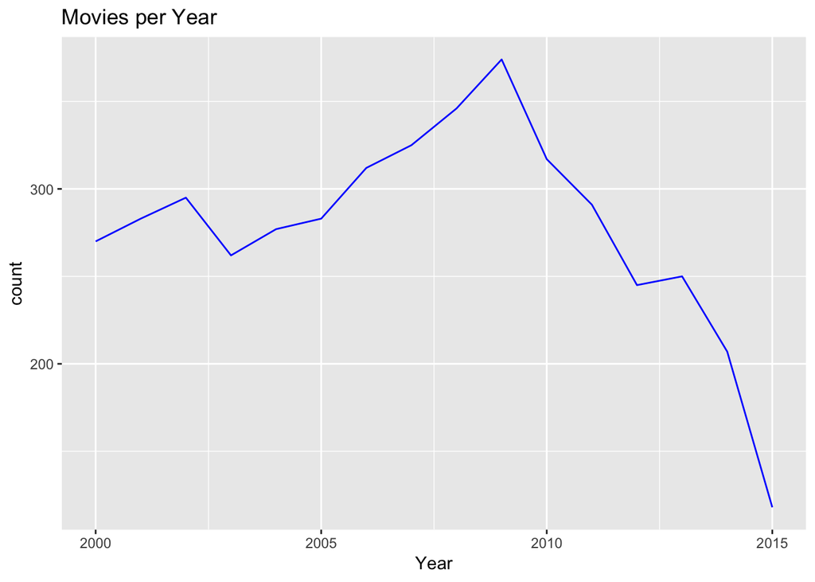

```r
movies_per_year %>%
  ggplot(aes(x = Year, y = count)) +
  geom_line(color="blue") +ggtitle("Movies per Year")
```

Movies released peaked during the years 2006-2009 with a sharp decline after that.

Rating count by Users

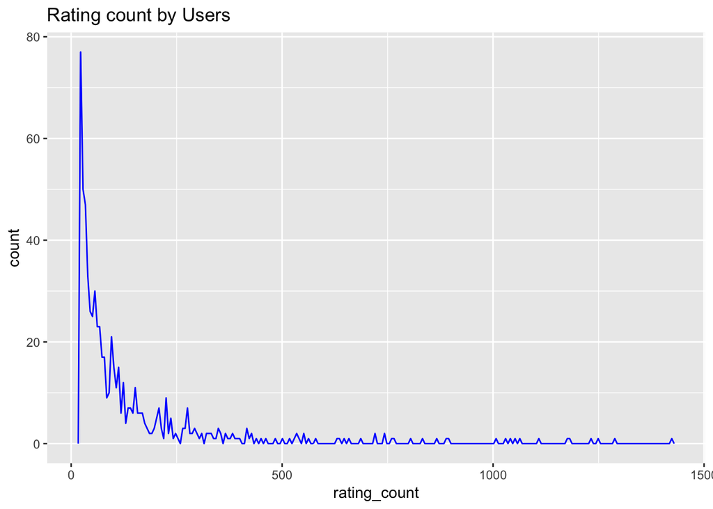

```r
User_ratings <- ratings %>% group_by(userId) %>% summarise(rating_count = n())
User_ratings_01 <- User_ratings %>% filter(rating_count <= 2000 )
#User_ratings_01 %>% ggplot(aes(x = userId, y=rating_count  )) + geom_col()
ggplot(User_ratings_01) + geom_freqpoly(aes(x=rating_count), bins =250, color = "blue")  +ggtitle("Rating count by Users")
```

The Maximum frequency of rating count per User is in the range of 0-75. We see few users have rated a large number of movies.

Creating one complete file

```r
movie_ratings <- movies_03 %>% inner_join(ratings, by="movieId")

movie_ratings_01 <- movie_ratings %>% inner_join(search, by="movieId")

 movie_ratings_02 <- movie_ratings_01[,-c(13,14)]
 glimpse(movie_ratings_02)
```

```
## Observations: 31,882
## Variables: 30
## $ movieId     <dbl> 2769, 2769, 2769, 2769, 3177, 3177, 3190, 3190, 3190…
## $ title.x     <chr> "Yards, The (2000)", "Yards, The (2000)", "Yards, Th…
## $ title_mv    <chr> "Yards, The", "Yards, The", "Yards, The", "Yards, Th…
## $ Year        <dbl> 2000, 2000, 2000, 2000, 2000, 2000, 2000, 2000, 2000…
## $ genre1      <chr> "Crime", "Crime", "Crime", "Crime", "Comedy", "Comed…
## $ genre2      <chr> "Drama", "Drama", "Drama", "Drama", NA, NA, "Sci-Fi"…
## $ genre3      <chr> NA, NA, NA, NA, NA, NA, "Thriller", "Thriller", "Thr…
## $ genre4      <chr> NA, NA, NA, NA, NA, NA, NA, NA, NA, NA, NA, NA, NA, …
## $ genre5      <chr> NA, NA, NA, NA, NA, NA, NA, NA, NA, NA, NA, NA, NA, …
## $ userId      <dbl> 451, 458, 607, 668, 232, 391, 63, 255, 310, 461, 607…
## $ rating      <dbl> 4.0, 2.0, 5.0, 3.5, 3.5, 5.0, 3.0, 2.0, 3.0, 2.5, 4.…
## $ timestamp   <dbl> 1130718427, 990057561, 1004865605, 1365263317, 12784…
## $ Action      <dbl> 0, 0, 0, 0, 0, 0, 0, 0, 0, 0, 0, 0, 0, 0, 0, 0, 0, 0…
```

[output cut: 17 more lines]

Movie Average Score

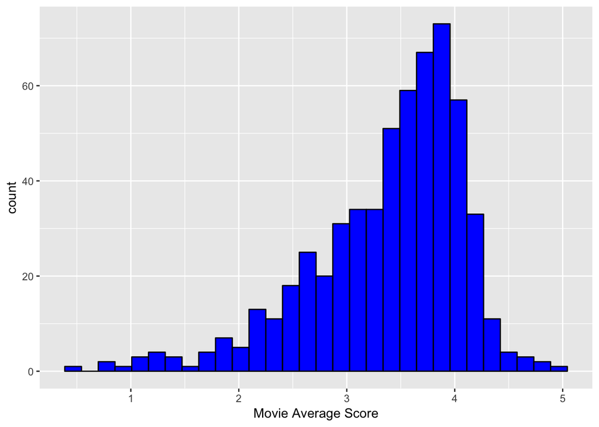

```r
Movieratings_cosine <- movie_ratings_02  %>% group_by(movieId) %>% summarize(avg_rating = mean(rating)) %>% arrange(desc(avg_rating))
Movieratings_cosine_01 <-  Movieratings_cosine %>% group_by(avg_rating) %>% count()
Movieratings_cosine_01  %>% ggplot(aes(x= avg_rating ), color=blue) + geom_histogram(bins =30, col= "black", fill="blue")+ xlab("Movie Average Score")
```

Few movies have got lower ratings as 1 , 2 or 5. We see that for the high count of ratings the score ranges between 3-4.5.

```r
movies_genreyear <- movie_ratings_02 %>% select(movieId, Year, genre1, genre2, genre3, genre4, genre5)
movies_genreyear_01 <- movies_genreyear %>% gather(MYear, Value, genre1:genre5)
movies_genreyear_01$Year = as.integer(movies_genreyear_01$Year)
movies_genreyear_02 <- movies_genreyear_01[,-3]


#MGenre
popular_genre  <- movies_genreyear_02 %>%
  select(Value , Year) %>%
  group_by(Value) %>%
  summarise(count = n())  %>%
  arrange(Value)
glimpse(popular_genre)
```

```
## Observations: 21
## Variables: 2
## $ Value <chr> "(no genres listed)", "Action", "Adventure", "Animation", …
## $ count <int> 4, 10962, 7712, 2437, 2191, 10489, 6134, 728, 14663, 3804,…
```

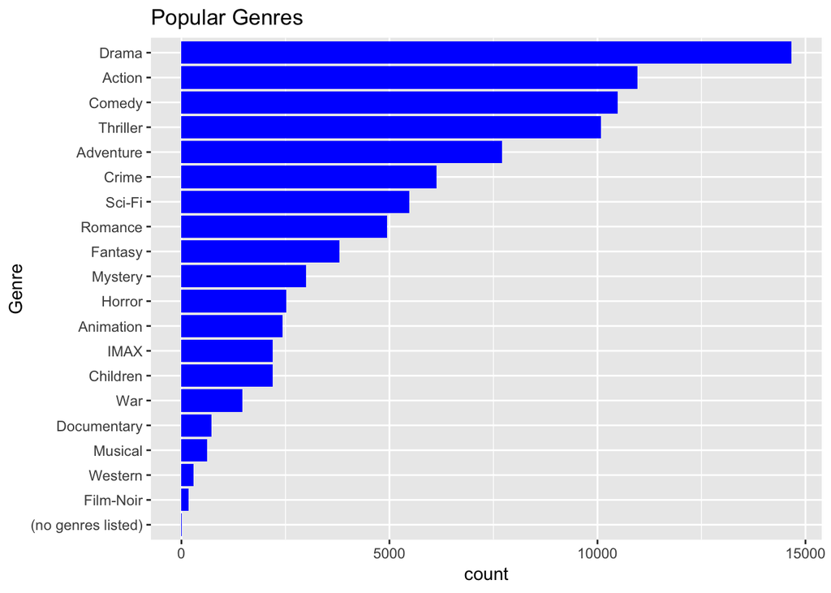

```r
#Popular Genres removing NA
popular_genre_01 <- popular_genre %>% filter(Value != "NA")
popular_genre_01 %>%  ggplot() + geom_col(aes(x=reorder(Value, count), y=count), fill = "blue") + coord_flip() +ggtitle("Popular Genres") +xlab("Genre")
```

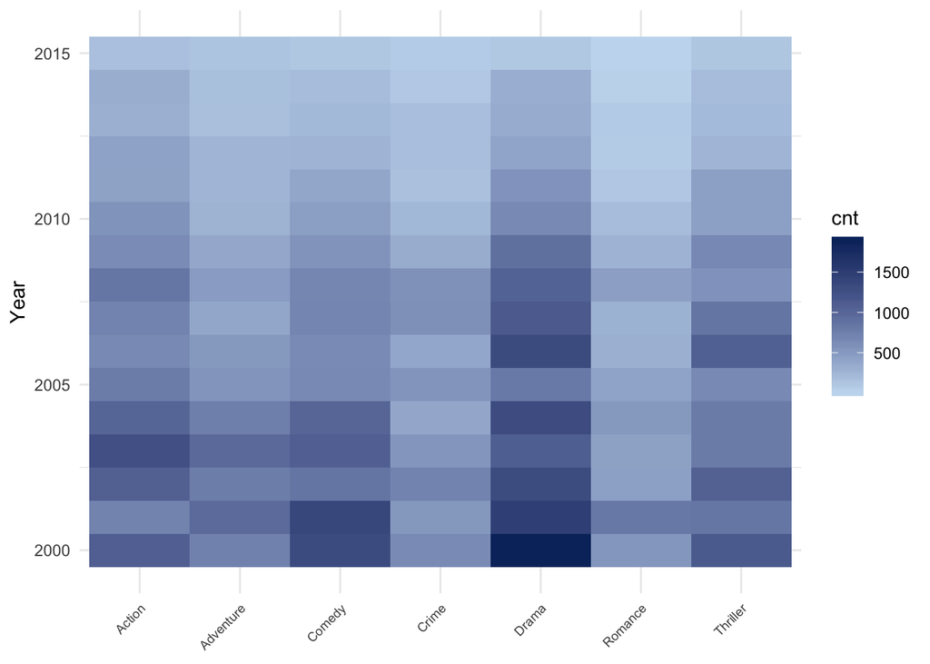

```r
#######
#movies_genreyear_02 %>% na.omit() %>%
  #filter(Value %in% c("Action", "Drama", "Comedy", "Thriller", "Romance", "Crime", "Adventure")) %>%
  #group_by(Year, Value) %>%
  #summarise(cnt = n()) %>%
  #ggplot(aes(x=Year, y=cnt)) + geom_line(aes(color=Value)) +ylab("Count")


#heat-map of  genre over the years
movies_genreyear_02 %>% na.omit() %>%
  filter(Value %in% c("Action", "Drama", "Comedy", "Thriller", "Romance", "Crime", "Adventure")) %>%
  group_by(Year, Value) %>%
  summarise(cnt = n()) %>%
  ggplot(aes(x = Year, y = Value)) +
  geom_tile(aes(fill = cnt)) +
  coord_flip() +
  scale_fill_gradient(low = "#C6DBEF", high = "#08306B") +
  theme_minimal() +theme(plot.title = element_text(size =10),axis.text.x = element_text(size =7,angle = 45, hjust =1),axis.title.x=element_blank())
```

User Similarity

```r
Userratings_cosine <- movie_ratings_02  %>% group_by(userId) %>% summarize(avg_rating = mean(rating)) %>% filter(userId <20)
glimpse(Userratings_cosine)
```

```
## Observations: 11
## Variables: 2
## $ userId     <dbl> 1, 5, 6, 7, 10, 12, 13, 15, 17, 18, 19
## $ avg_rating <dbl> 3.767857, 3.903226, 4.128205, 3.269841, 4.125000, 4.0…
```

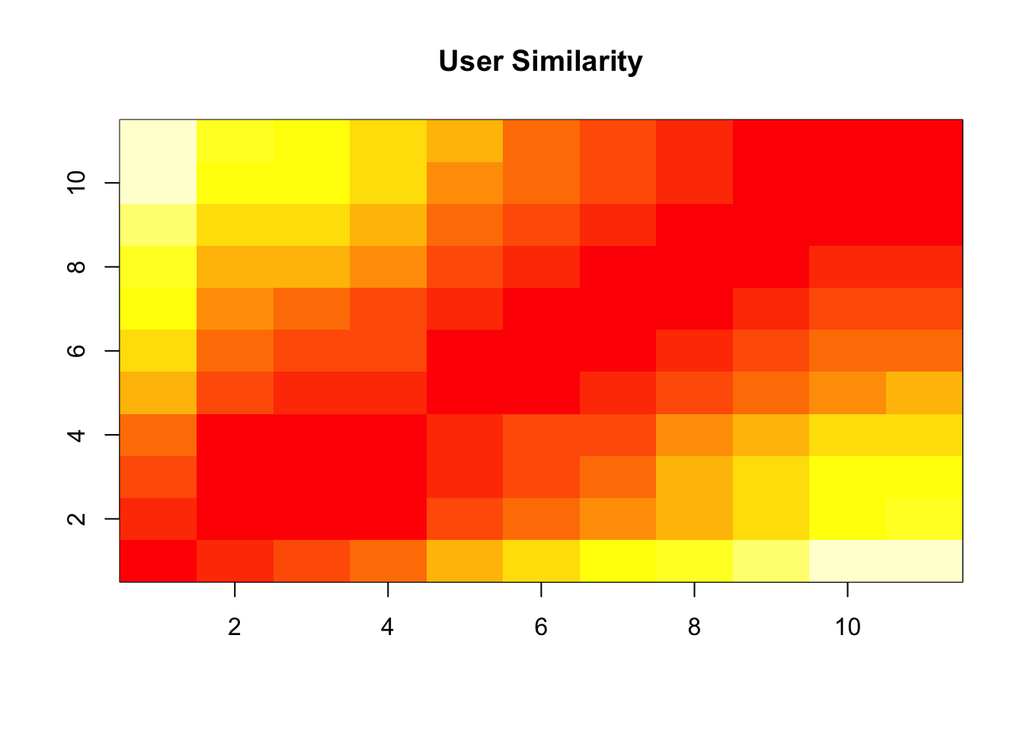

```r
dst=dist(Userratings_cosine[1:17,])
dst1 = data.matrix(dst)
dst2 <- dst1[1:11, 1:11]
dim <- ncol(dst2)

image(1:dim, 1:dim, dst2, xlab="", ylab = "" )
title("User Similarity")
```

The file rating cosine has been formed by joining ratings with movies between 2000-2016. In the given matrix, each row and each column corresponds to a user and each cell corresponds to the similarity between the two users. The more red the cell is, the more similar the two users are in ratings.

Movies Similarity

```r
Movieratings_cosine <- movie_ratings_02  %>% group_by(movieId) %>% summarize(avg_rating = mean(rating)) %>% arrange(desc(avg_rating))
Movieratings_cosine_01 <-  Movieratings_cosine %>% group_by(avg_rating) %>% count()
glimpse(Movieratings_cosine)
```

```
## Observations: 4,453
## Variables: 2
## $ movieId    <dbl> 3914, 6190, 6672, 6902, 9010, 27366, 27456, 27792, 27…
## $ avg_rating <dbl> 5, 5, 5, 5, 5, 5, 5, 5, 5, 5, 5, 5, 5, 5, 5, 5, 5, 5,…
```

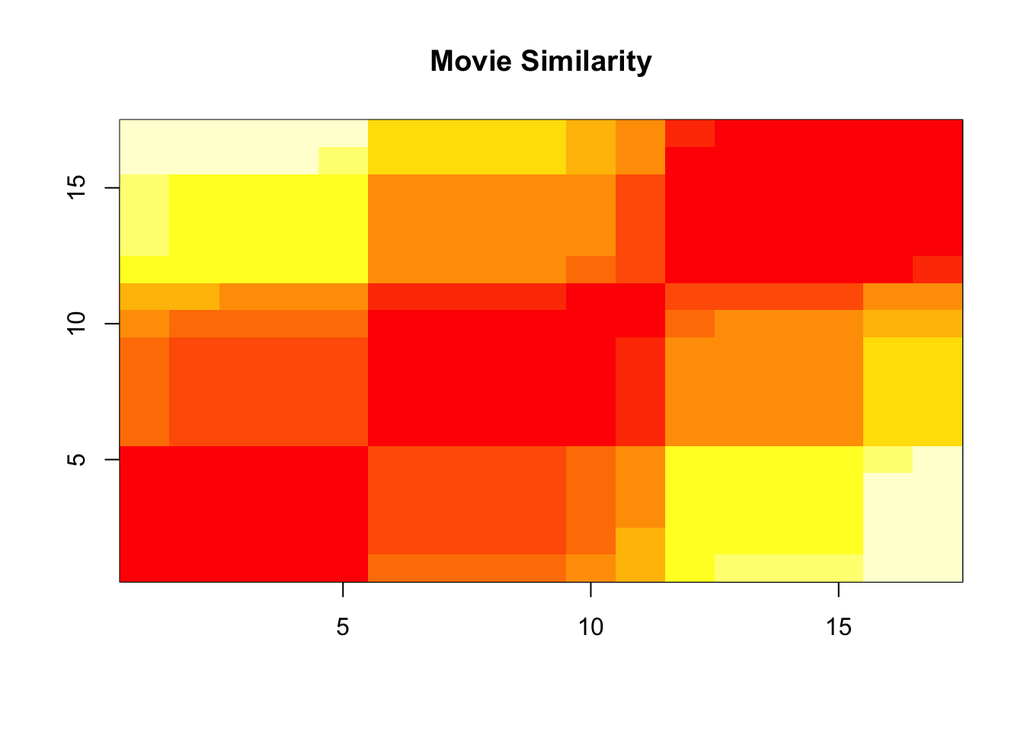

```r
dst=dist(Movieratings_cosine[1:17,])
dst1 = data.matrix(dst)
dst2 <- dst1[1:17, 1:17]
dim <- ncol(dst2)

image(1:dim, 1:dim, dst2, xlab="", ylab = "" )
title("Movie Similarity")
```

The file rating cosine has been formed by joining ratings with movies between 2000-2016. In the given matrix, each row and each column corresponds to a movie and each cell corresponds to the similarity between the two movies. The more red the cell is, the more similar the two movies are in ratings.

Creating the Rating matrix

```r
ratingmat <- dcast(movie_ratings_02, userId~movieId, value.var = "rating", na.rm=FALSE)
ratingmat <- as.matrix(ratingmat[,-1])

#Convert rating matrix into a recommenderlab sparse matrix
ratingmat <- as(ratingmat, "realRatingMatrix")
ratingmat
```

```
## 431 x 4453 rating matrix of class 'realRatingMatrix' with 31882 ratings.
```

In order to use the rating data for building recommendation engine with *recommenderlab*, we converted rating matrix into a sparse matrix of type *realRatingMatrix*. The rows asre userid and the columns are movieID and the values are the ratings.

Exploring Parameters of Recommendation Models

```r
recommender_models <- recommenderRegistry$get_entries(dataType = "realRatingMatrix")
names(recommender_models)
```

```
## [1] "ALS_realRatingMatrix"          "ALS_implicit_realRatingMatrix"
## [3] "IBCF_realRatingMatrix"         "POPULAR_realRatingMatrix"
## [5] "RANDOM_realRatingMatrix"       "RERECOMMEND_realRatingMatrix"
## [7] "SVD_realRatingMatrix"          "SVDF_realRatingMatrix"
## [9] "UBCF_realRatingMatrix"
```

```r
lapply(recommender_models, "[[", "description")
```

```
## $ALS_realRatingMatrix
## [1] "Recommender for explicit ratings based on latent factors, calculated by alternating least squares algorithm."
##
## $ALS_implicit_realRatingMatrix
## [1] "Recommender for implicit data based on latent factors, calculated by alternating least squares algorithm."
##
## $IBCF_realRatingMatrix
## [1] "Recommender based on item-based collaborative filtering."
##
## $POPULAR_realRatingMatrix
## [1] "Recommender based on item popularity."
##
## $RANDOM_realRatingMatrix
## [1] "Produce random recommendations (real ratings)."
##
## $RERECOMMEND_realRatingMatrix
## [1] "Re-recommends highly rated items (real ratings)."
##
## $SVD_realRatingMatrix
## [1] "Recommender based on SVD approximation with column-mean imputation."
##
## $SVDF_realRatingMatrix
## [1] "Recommender based on Funk SVD with gradient descend."
##
## $UBCF_realRatingMatrix
## [1] "Recommender based on user-based collaborative filtering."
```

We will be using IBCF and UBCF models. Checking the parameters of the two models.

```r
recommender_models$IBCF_realRatingMatrix$parameters
```

```
## $k
## [1] 30
##
## $method
## [1] "Cosine"
##
## $normalize
## [1] "center"
##
## $normalize_sim_matrix
## [1] FALSE
##
## $alpha
## [1] 0.5
##
## $na_as_zero
## [1] FALSE
```

```r
recommender_models$UBCF_realRatingMatrix$parameters
```

```
## $method
## [1] "cosine"
##
## $nn
## [1] 25
##
## $sample
## [1] FALSE
##
## $normalize
## [1] "center"
```

Exploring the rating matrix

```r
vect_ratings <- as.vector(ratingmat@data)
unique(vect_ratings)
```

```
##  [1] 0.0 4.0 2.0 5.0 3.5 3.0 2.5 1.5 0.5 1.0 4.5
```

```r
vect_ratings_01 <- table(vect_ratings)
vect_ratings_01
```

```
## vect_ratings
##       0     0.5       1     1.5       2     2.5       3     3.5       4
## 1887361     537     820     800    2115    2612    5059    5419    7687
##     4.5       5
##    3624    3209
```

Heatmap of Rating Matrix

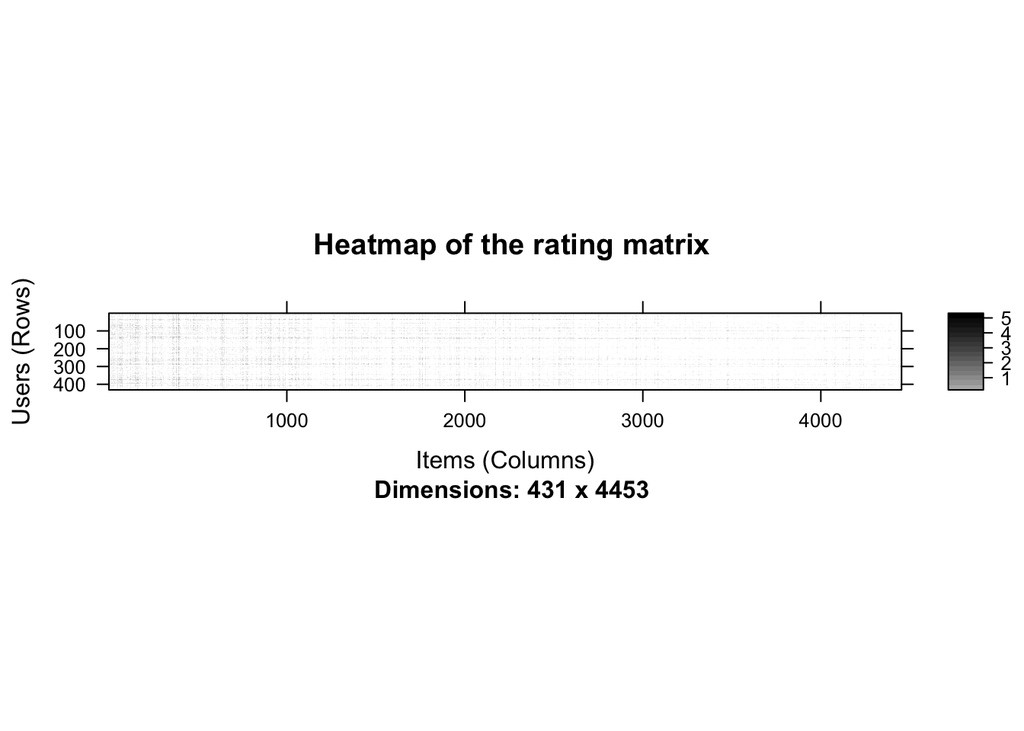

```r
image(ratingmat, main = "Heatmap of the rating matrix")
```

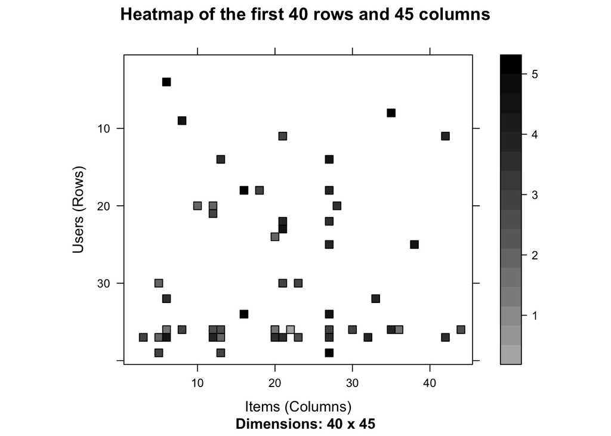

```r
image(ratingmat[1:40, 1:45], main = "Heatmap of the first 40 rows and 45 columns")
```

Since there are too many users and movers, the first heat map is hard to interpret. The second Heat map is built zooming into the first rows and columns.

Distribution of vector ratings

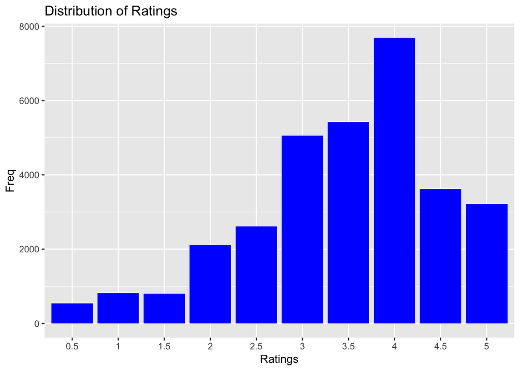

```r
vect_ratings_02 <- data.frame(vect_ratings_01)
vect_ratings_03 <- vect_ratings_02 %>% filter(vect_ratings != 0)
vect_ratings_03 %>% ggplot(aes(x=vect_ratings ,y=Freq)) + geom_col( fill="blue") + xlab("Ratings") + ggtitle("Distribution of Ratings ")
```

The graph shows that there are very less rating scores less than 2.0. The most common rating is 4.0.

Number of views of the top movies

```r
Highrated_movies <- movie_ratings_02 %>% group_by(movieId, title.x) %>% summarise(avg_rating= round(mean(rating), 2), Rt_cnt = n()) %>% arrange(desc(Rt_cnt))
colnames(Highrated_movies) = c("MovieID", "Title", "Average_rating", "Rating_count")
knitr::kable(Highrated_movies[1:15,])
```

| MovieID | Title | Average_rating | Rating_count |
| --- | --- | --- | --- |
| 4993 | Lord of the Rings: The Fellowship of the Ring, The (2001) | 4.13 | 189 |
| 5952 | Lord of the Rings: The Two Towers, The (2002) | 4.10 | 167 |
| 7153 | Lord of the Rings: The Return of the King, The (2003) | 4.11 | 166 |
| 3578 | Gladiator (2000) | 4.05 | 164 |
| 4306 | Shrek (2001) | 3.76 | 158 |
| 4226 | Memento (2000) | 4.06 | 156 |
| 6539 | Pirates of the Caribbean: The Curse of the Black Pearl (2003) | 3.83 | 141 |
| 3793 | X-Men (2000) | 3.56 | 130 |
| 58559 | Dark Knight, The (2008) | 4.14 | 127 |
| 4963 | Ocean’s Eleven (2001) | 3.74 | 119 |
| 4973 | Amelie (Fabuleux destin d’Amélie Poulain, Le) (2001) | 4.08 | 119 |
| 6377 | Finding Nemo (2003) | 3.89 | 117 |
| 4886 | Monsters, Inc. (2001) | 3.88 | 116 |
| 5418 | Bourne Identity, The (2002) | 3.89 | 113 |
| 3996 | Crouching Tiger, Hidden Dragon (Wo hu cang long) (2000) | 3.97 | 112 |

```r
Highrated_movies_02 <-  movie_ratings_02 %>% summarise(min_rating = min(rating), max_rating = max(rating), avg_rating = round(mean(rating), 2))
knitr::kable(Highrated_movies_02)
```

| min_rating | max_rating | avg_rating |
| --- | --- | --- |
| 0.5 | 5 | 3.46 |

```r
#Getting the count of Users who rated the movies.
views_per_movie <- colCounts(ratingmat)

#create data frame of movie with the views
movie_views <- data.frame(movieId = as.integer(names(views_per_movie)),
                          views = views_per_movie) # create dataframe of views

movie_views_01 <- movie_views %>% left_join(movie_ratings_02, by = "movieId") %>% select(movieId, views, title_mv, Year, title.x)

movie_views_02 <- unique(movie_views_01)
glimpse(movie_views_02)
```

```
## Observations: 4,453
## Variables: 5
## $ movieId  <dbl> 2769, 3177, 3190, 3225, 3273, 3275, 3276, 3285, 3286, 3…
## $ views    <int> 4, 2, 6, 2, 31, 43, 2, 25, 1, 1, 23, 39, 35, 1, 13, 23,…
## $ title_mv <chr> "Yards, The", "Next Friday", "Supernova", "Down to You"…
## $ Year     <dbl> 2000, 2000, 2000, 2000, 2000, 2000, 2000, 2000, 2000, 2…
## $ title.x  <chr> "Yards, The (2000)", "Next Friday (2000)", "Supernova (…
```

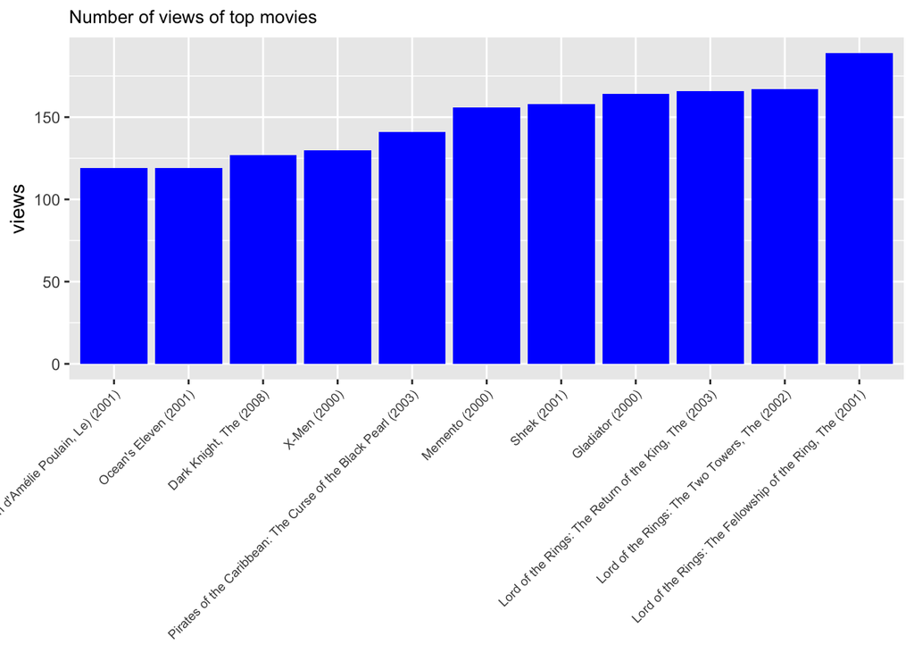

```r
movie_views_03 <- movie_views_02 %>% arrange(desc(views))

movie_views_03 %>%  top_n(  n=10, views) %>% ggplot(aes(x=reorder(title.x,views),  y=views)) + geom_col( fill="blue") + theme(plot.title = element_text(size =10),axis.text.x = element_text(size =7,angle = 45, hjust =1),axis.title.x=element_blank()) + ggtitle("Number of views of top movies")
```

Average Movie ratings

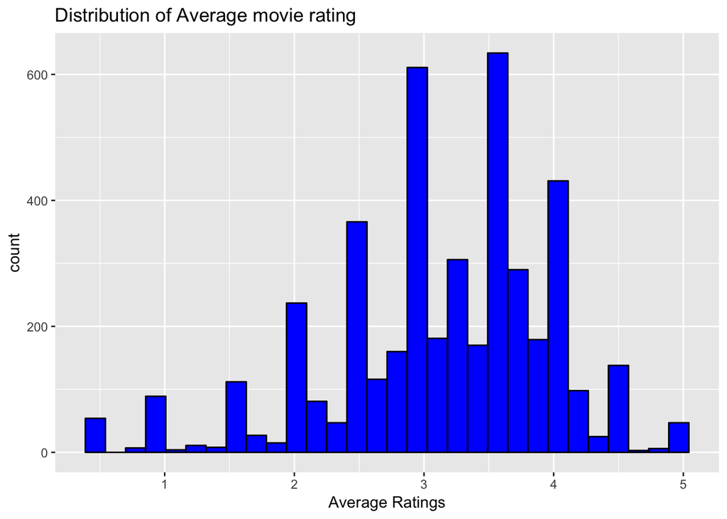

```r
#getting the average ratings of each movie
average_ratings <- colMeans(ratingmat)

#create data frame of movie with the average ratings
movie_ratings <- data.frame(movieId = as.integer(names(average_ratings)),
                          movieratings = average_ratings)

movie_ratings %>% ggplot(aes(x= movieratings), color=blue) + geom_histogram(bins =30, col= "black", fill="blue")+ xlab("Average Ratings") + ggtitle("Distribution of Average movie rating")
```

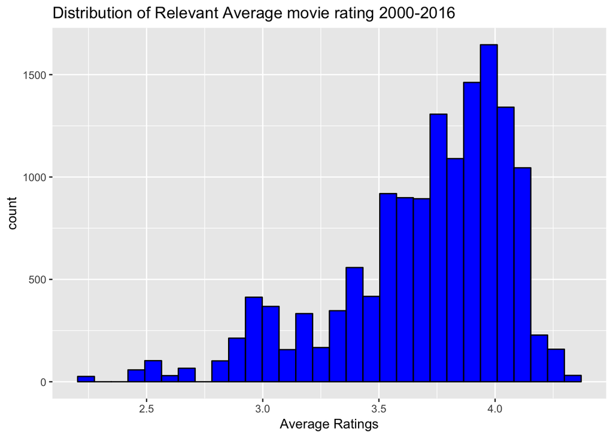

```r
# considering the average ratings of Users with relevant views >25
  movie_ratings %>% left_join(movie_views_01 , by = "movieId")  %>% filter(views > 25) %>% ggplot(aes(x= movieratings), color=blue) + geom_histogram(bins =30, col= "black", fill="blue")+ xlab("Average Ratings") + ggtitle("Distribution of Relevant Average movie rating 2000-2016")
```

The first image above shows the distribution of the average movie ratings. The highest value is around 3.5. There are very few movies whose ratings are below 2 or greater than 4.5. This may be dependent upon the Users.

Some Users saw more movies than others. Similarly some movies have been rated more than the others. So we need to select the most relevant movies and users.

Selecting Users who have rated many movies and movies that have rated by many users.

```r
min_movies <- quantile(rowCounts(ratingmat), 0.99)
print("Minimum number of movies per user:")
```

```
## [1] "Minimum number of movies per user:"
```

```r
min_movies
```

```
##   99%
## 770.6
```

```r
min_users <- quantile(colCounts(ratingmat), 0.99)
print("Minimum number of users per movie:")
```

```
## [1] "Minimum number of users per movie:"
```

```r
min_users
```

```
## 99%
##  72
```

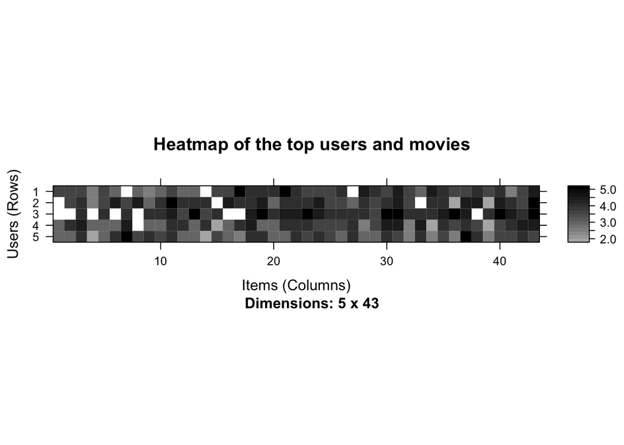

```r
image(ratingmat[rowCounts(ratingmat) > min_movies,
                 colCounts(ratingmat) > min_users],
main = "Heatmap of the top users and movies")
```

Most of the users have watched all the top movies, if we look row-wise, dark cells represents users have given higher ratings and column wise the darker shades is interpreted as movies which are rated the highest. So it sis good to normalize the data.

Data Preparation  
1. Select the relevant data  
2. Normalize the data  
3. Binarize the data

1. Selecting movies with views > 25 and users per rated movies > 25 (Year:2000=2016)

```r
ratings_movies <- ratingmat[rowCounts(ratingmat) > 25,
                             colCounts(ratingmat) > 25]
ratings_movies
```

```
## 234 x 281 rating matrix of class 'realRatingMatrix' with 12983 ratings.
```

This selection has 234 Users and 281 movies.

Repeating to see how the heat map and the average ratings look like for the selection.

```r
min_movies_sel <- quantile(rowCounts(ratings_movies), 0.98)
print("Minimum number of movies per user:")
```

```
## [1] "Minimum number of movies per user:"
```

```r
min_movies_sel
```

```
##    98%
## 200.38
```

```r
min_users_sel <- quantile(colCounts(ratings_movies), 0.98)
print("Minimum number of users per movie:")
```

```
## [1] "Minimum number of users per movie:"
```

```r
min_users_sel
```

```
##   98%
## 126.2
```

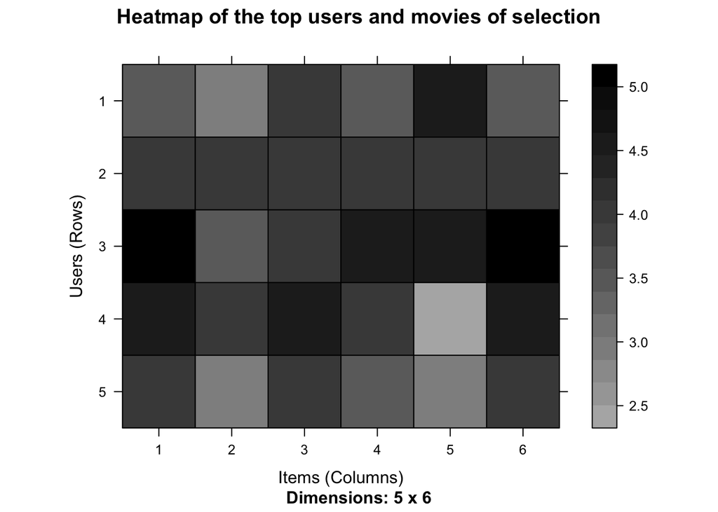

```r
image(ratings_movies[rowCounts(ratings_movies) > min_movies_sel,
                 colCounts(ratings_movies) > min_users_sel],
main = "Heatmap of the top users and movies of selection")
```

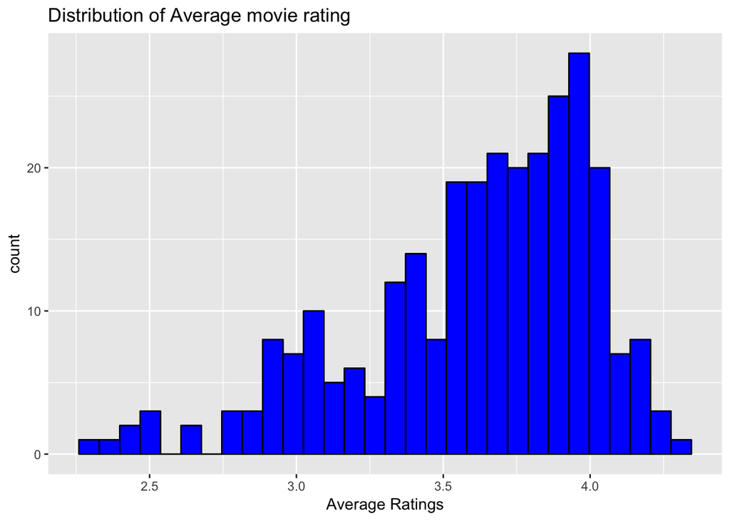

```r
#getting the average ratings of each movie
average_ratings_sel <- colMeans(ratings_movies)

#create data frame of movie with the average ratings
movie_ratings_sel <- data.frame(movieId = as.integer(names(average_ratings_sel)),
                          movieratings = average_ratings_sel)

movie_ratings_sel %>% ggplot(aes(x= movieratings), color=blue) + geom_histogram(bins =30, col= "black", fill="blue")+ xlab("Average Ratings") + ggtitle("Distribution of Average movie rating")
```

The shades are darker which means users are giving high ratings to many movies. This is also evident in average ratings where we see the distribution varies a lot.

Normalizing Data

```r
ratings_movies_norm <- normalize(ratings_movies)
sum(rowMeans(ratings_movies_norm) > 0.00001)
```

```
## [1] 0
```

If users give high or low rating to all movies, it will result in bias. In order to remove this effect, we normalized the data such that average rating of each user is 0.

Visualizing the normalized data

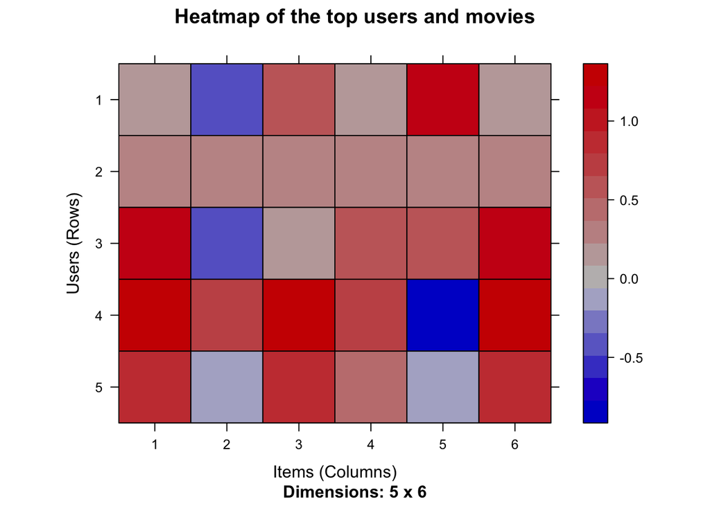

```r
image(ratings_movies_norm[rowCounts(ratings_movies_norm) > min_movies_sel,
                          colCounts(ratings_movies_norm) > min_users_sel],
main = "Heatmap of the top users and movies")
```

The heat map is colored as the data is continuous.

Binarizing data Also the rating can be more of aspirational values rather than revealed values. The Likert Scale is the most universal method of survey collection. it does not force the participant to take a stand on a topic but allows them to respond in degree of agreement. The dis-advantage is that it is uni-dimensional and gives ony 5-7 options of choice and the space between the choices cannot possibly be equidistant. And it is not unlikely that users answers will be influenced and may not be his/her real response.

Some recommendation model work on binary data, so it might be useful to binarize the data, that is define a table containing only 0s and 1s. There may be manyscenarios:

- Define a matrix having 1 if the user rated the movies and 0 otherwise. In this case, the information about the rating scale is lost.

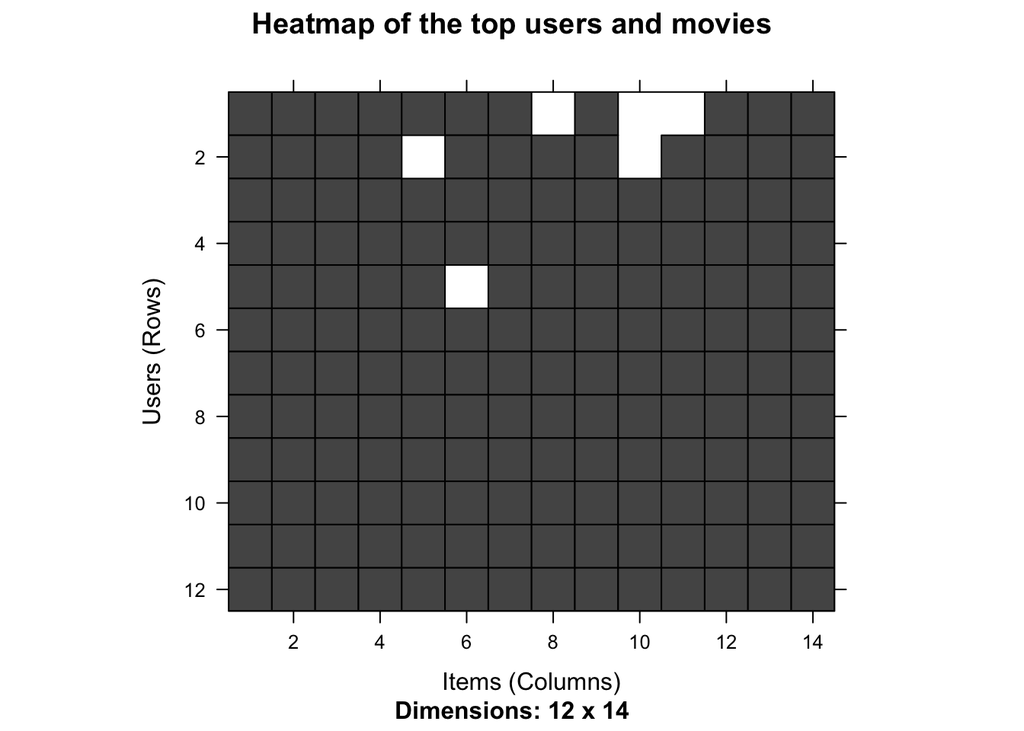

```r
ratings_movies_watched <- binarize(ratings_movies, minRating = 1)
min_movies_binary <- quantile(rowCounts(ratings_movies), 0.95)
min_users_binary <- quantile(colCounts(ratings_movies), 0.95)
image(ratings_movies_watched[rowCounts(ratings_movies) > min_movies_binary,
                             colCounts(ratings_movies) > min_users_binary],
main = "Heatmap of the top users and movies")
```

- Define a matrix having 1 if the rating is above or equal to a threshold (for example 2) and 0 otherwise. In this case, giving a bad rating to movie is equivalent to not having rated it.

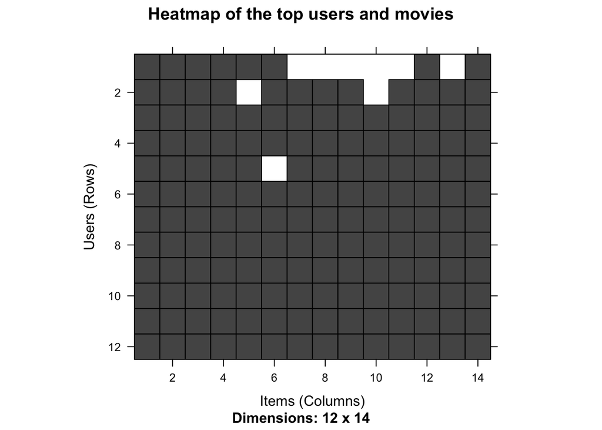

```r
ratings_movies_good <- binarize(ratings_movies, minRating = 2)
image(ratings_movies_good[rowCounts(ratings_movies) > min_movies_binary,
colCounts(ratings_movies) > min_users_binary],
main = "Heatmap of the top users and movies")
```

- Define a matrix having 1 if the rating is above or equal to a threshold (for example 3) and 0 otherwise. In this case, giving a bad rating to movie is equivalent to not having rated it.

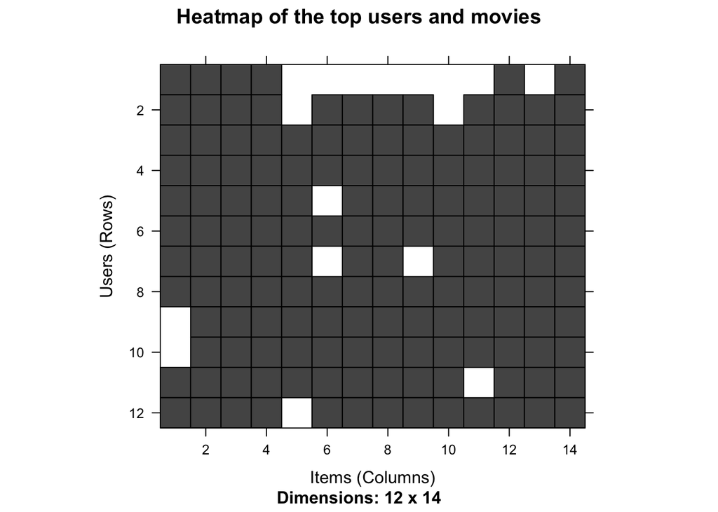

```r
ratings_movies_good <- binarize(ratings_movies, minRating = 3)
image(ratings_movies_good[rowCounts(ratings_movies) > min_movies_binary,
colCounts(ratings_movies) > min_users_binary],
main = "Heatmap of the top users and movies")
```

There are more white cells in the third heat map, which shows there are more movies with no or bad ratings.

ITEM based Collaborative Filtering Model The word “Collaborative” means users collaborate with each other to recommend items. We use the rating matrix in which rows correspond to UserID and columns correspond to movieId. The core algorithm is based on these steps: 1. For each two movies, measure how similar they are in terms of ratings received. 2. For each movie, identify the k most similar movies. 3. For each user, identify the movies that are the most similar to the users ratings.

Defining training/test sets

```r
set.seed(1234)
train_data  <- sample(x = c(TRUE, FALSE),
                      size = nrow(ratings_movies),
                      replace = TRUE,
                      prob = c(0.8, 0.2))
recc_train <- ratings_movies[train_data, ]
recc_test <- ratings_movies[-train_data, ]
```

Building the Recommendation Model default parameters of IBCF model. Here,  
*k* is the number of items to compute the similarities among them in the first step. After, for each item, the algorithm identifies its *k* most similar items and stores the number.  
*method* is a similarity funtion, which is *Cosine* by default, may also be *pearson*. We create the model using the default parameters of method = Cosine and k=30.

```r
recommender_models <- recommenderRegistry$get_entries(dataType ="realRatingMatrix")
recommender_models$IBCF_realRatingMatrix$parameters
```

```
## $k
## [1] 30
##
## $method
## [1] "Cosine"
##
## $normalize
## [1] "center"
##
## $normalize_sim_matrix
## [1] FALSE
##
## $alpha
## [1] 0.5
##
## $na_as_zero
## [1] FALSE
```

```r
recc_model <- Recommender(data = recc_train,
                          method = "IBCF",
                          parameter = list(k = 30))

recc_model
```

```
## Recommender of type 'IBCF' for 'realRatingMatrix'
## learned using 190 users.
```

```r
class(recc_model)
```

```
## [1] "Recommender"
## attr(,"package")
## [1] "recommenderlab"
```

Exploring the recommender model

```r
model_details <- getModel(recc_model)
names(model_details)
```

```
## [1] "description"          "sim"                  "k"
## [4] "method"               "normalize"            "normalize_sim_matrix"
## [7] "alpha"                "na_as_zero"           "verbose"
```

```r
class(model_details$sim)
```

```
## [1] "dgCMatrix"
## attr(,"package")
## [1] "Matrix"
```

```r
dim(model_details$sim)
```

```
## [1] 281 281
```

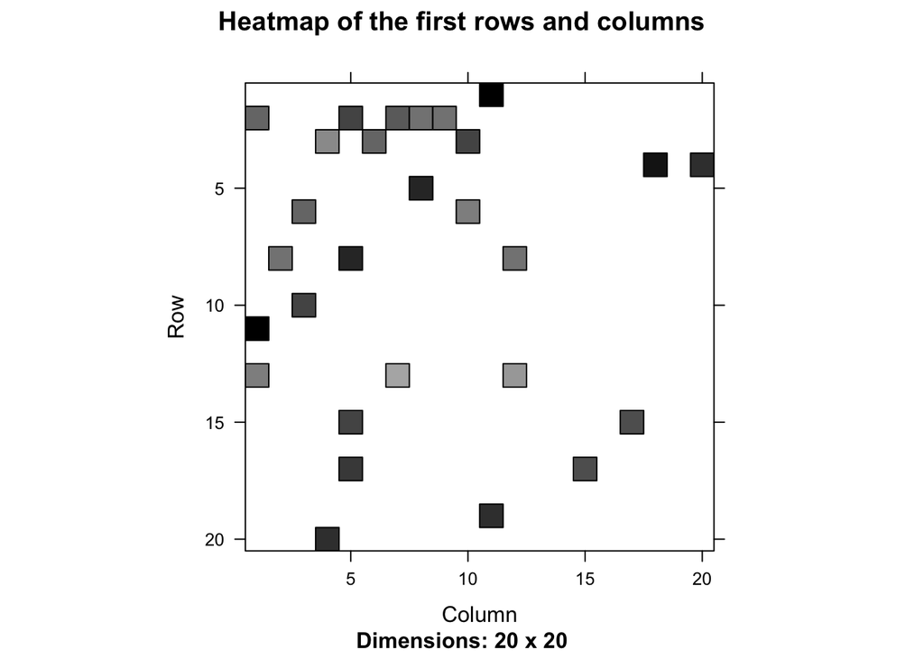

```r
#heat map top 20 rows and columns
top_movies <- 20
image(model_details$sim[1:top_movies, 1:top_movies],
      main = "Heatmap of the first rows and columns")
```

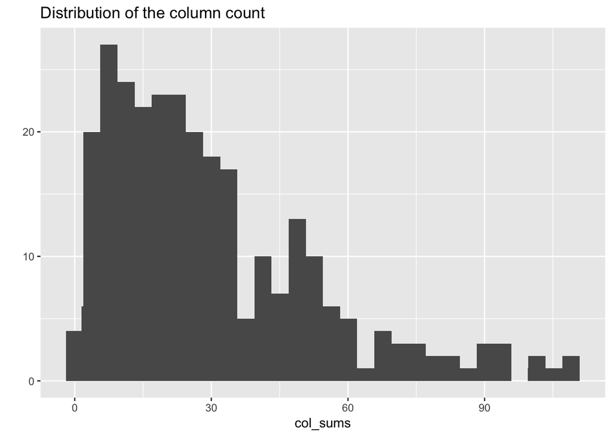

```r
col_sums <- colSums(model_details$sim > 0)
qplot(col_sums) + stat_bin(binwidth = 1) + ggtitle("Distribution of the column count")
```

dgCMatrix is the Similarity Matrix created by the model.

It’s dimensions are 281 X 281 which is equal to the number of movies.

The heat map of the first 20 rows and columns show that many values are 0. Each row contains k =30 elements that are greater than 0. The matrix is not symmetric. The number of non-null elements for each column depends on how many times the corresponding movie was included in the top k of another movie.

The chart of the distribution of the number of elements by columns shows that there are few movies that are similar to many others.

Applying Recommender system on the dataset  
Now, it is possible to recommend movies to the users in the test set.

Define *n_recommended* equal to 10 that specifies the number of movies to recommend to each user.

For each user, the algorithm extracts its rated movies. For each movie, it identifies all its similar movies, starting from the similarity matrix. Then, the algorithm ranks each similar movies in this way:

- Extract the user rating associated with this movie. The rating is used as a weight.
- Extract the similarity of the movie with each rating associated with this movie.
- Multiply each weight with the related similarity.
- Sum everything up.

Then, the algorithm identifies the top 10 recommendations:

```r
recc_predicted <- predict(object = recc_model,
                          newdata = recc_test,
                          n = 10)
recc_predicted
```

```
## Recommendations as 'topNList' with n = 10 for 233 users.
```

Exploring the results of recommendation for the first user

```r
recc_user_1 <- recc_predicted@items[[1]]
movies_user_1 <- recc_predicted@itemLabels[recc_user_1]


movies_user_2 <- as.data.frame(movies_user_1)
colnames(movies_user_2) <- c("movieId")
movies_user_2$movieId <- as.character(movies_user_2$movieId)
movies_user_2$movieId <- as.numeric(movies_user_2$movieId)
movies_user_3 <- sqldf("select * from movies where movieId in (select movieId from movies_user_2)") %>% select(movieId, title)
movies_user_3
```

```
##    movieId                                               title
## 1     3408                              Erin Brockovich (2000)
## 2     3555                                        U-571 (2000)
## 3     3863                                    Cell, The (2000)
## 4     4370                 A.I. Artificial Intelligence (2001)
## 5     4878                                 Donnie Darko (2001)
## 6     4975                                  Vanilla Sky (2001)
## 7     5378 Star Wars: Episode II - Attack of the Clones (2002)
## 8     5991                                      Chicago (2002)
## 9     6378                             Italian Job, The (2003)
## 10    7373                                      Hellboy (2004)
```

It’s also possible to define a matrix with the recommendations for each user. Visualize the recommendations for the first four users:

```r
recc_matrix <- sapply(recc_predicted@items,
                      function(x){ as.integer(colnames(ratings_movies)[x]) })
 recc_matrix_01  <- matrix(unlist(recc_matrix), ncol=10, byrow = TRUE)
 recc_matrix_01[1:4,]
```

```
##       [,1]  [,2]  [,3]  [,4] [,5] [,6] [,7]  [,8] [,9] [,10]
## [1,]  3408  3555  3863  4370 4878 4975 5378  5991 6378  7373
## [2,]  3481  3948  3988  3996 4014 4019 4022  4308 4718  5010
## [3,] 34405 41566 63082 30793 4874 3510 6016  6870 3863  5872
## [4,]  4015 54259 54272 68237 3948 4370 7451 64957 7293  6934
```

Here the rows are the first 4 users and the each row has the movieid values recommended for 10 movies.

Now, let’s identify the most recommended movies. The following image shows the distribution of the number of items for IBCF:

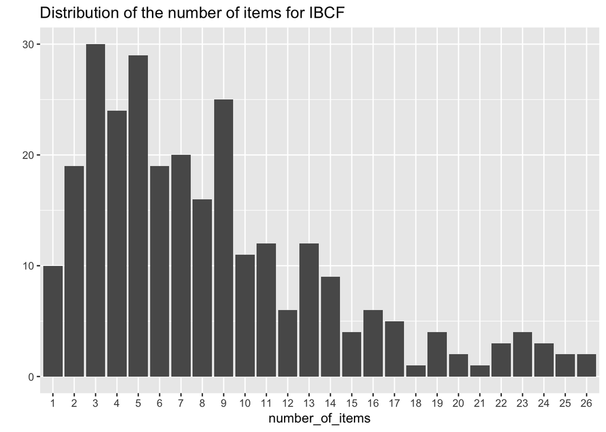

```r
number_of_items <- factor(table(recc_matrix_01))

chart_title <- "Distribution of the number of items for IBCF"
qplot(number_of_items) + ggtitle(chart_title)
```

```r
number_of_items_sorted <- sort(number_of_items, decreasing = TRUE)
number_of_items_top <- head(number_of_items_sorted, n = 4)
table_top <- data.frame(as.integer(names(number_of_items_top)),
                       number_of_items_top)



colnames(table_top) <- c("movieId", "number")
movies_user_03 <- sqldf("select a.movieId, a.title, b.number from movies a, table_top b where a.movieId = b.movieId")
movies_user_04 <- unique(movies_user_03)%>% arrange(desc(number))
knitr::kable(movies_user_04)
```

| movieId | title | number |
| --- | --- | --- |
| 3555 | U-571 (2000) | 26 |
| 3624 | Shanghai Noon (2000) | 26 |
| 3273 | Scream 3 (2000) | 25 |
| 3510 | Frequency (2000) | 25 |

Most of the movies have been recommended only a few times, and a few movies have been recommended more than 15 times.

IBCF recommends items on the basis of the similarity matrix. For each item, the model stores the k-most similar, so the amount of information is small once the model is built. This is an advantage in the presence of lots of data.

In addition, this algorithm is efficient and scalable, so it works well with big rating matrices.

USER-based Collaborative Filtering Model

According to this approach, given a new user, its similar users are first identified. Then, the top-rated movies rated by similar users are recommended.

For each new user, these are the steps:

1. Measure how similar each user is to the new one. Like IBCF, popular similarity measures are correlation and cosine.
2. Identify the most similar users. The options are:
- Take account of the top k users (k-nearest_neighbors)
- Take account of the users whose similarity is above a defined threshold
3. Rate the movies rated by the most similar users. The rating is the average rating among similar users and the approaches are:
- Average rating
- Weighted average rating, using the similarities as weights
4. Pick the top-rated movies.

##### Building the recommendation system:

Again, let’s first check the default parameters of UBCF model. Here, *nn* is a number of similar users, and *method* is a similarity function, which is *cosine* by default.

```r
recommender_models <- recommenderRegistry$get_entries(dataType ="realRatingMatrix")
recommender_models$UBCF_realRatingMatrix$parameters
```

```
## $method
## [1] "cosine"
##
## $nn
## [1] 25
##
## $sample
## [1] FALSE
##
## $normalize
## [1] "center"
```

```r
recc_model <- Recommender(data = recc_train, method = "UBCF")
recc_model
```

```
## Recommender of type 'UBCF' for 'realRatingMatrix'
## learned using 190 users.
```

```r
model_details <- getModel(recc_model)

model_details$data
```

```
## 190 x 281 rating matrix of class 'realRatingMatrix' with 10033 ratings.
## Normalized using center on rows.
```

Applying the recommender model on the test set

In the same way as the IBCF, determine the top ten recommendations for each new user in the test set.

```r
recc_predicted <- predict(object = recc_model,
                          newdata = recc_test,
                          n = 10)
recc_predicted
```

```
## Recommendations as 'topNList' with n = 10 for 233 users.
```

Explore results

Let’s take a look at the first four users:

```r
recc_matrix <- sapply(recc_predicted@items,
                      function(x){ as.integer(colnames(ratings_movies)[x]) })

 recc_matrix_02  <- matrix(unlist(recc_matrix), ncol=10, byrow = TRUE)
 recc_matrix_02[1:4,]
```

```
##      [,1] [,2] [,3] [,4] [,5]  [,6] [,7]  [,8]  [,9] [,10]
## [1,] 4011 4973 4034 3949 3275 49530 5956  5299  7502 30707
## [2,] 6539 4226 4993 4973 5952  7153 3948  3578  6502  5991
## [3,] 4226 4973 5902 5010 4641  4848 4995 46578 68954  5673
## [4,] 5618 6874 7361 4226 7438  5010 3996  4979 63082  3967
```

The above matrix contain *movieId* of each recommended movie (columns) for the first four users (rows) in our test dataset.

Compute how many times each movie got recommended and build the related frequency histogram:

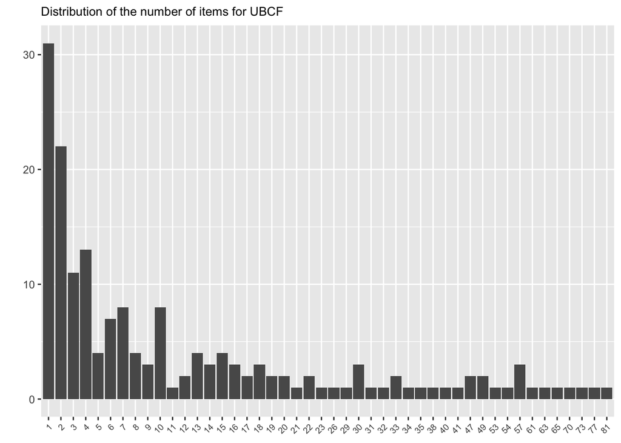

```r
number_of_items <- factor(table(recc_matrix_02))


chart_title <- "Distribution of the number of items for UBCF"
qplot(number_of_items) + ggtitle(chart_title) +theme(plot.title = element_text(size =10),axis.text.x = element_text(size =7,angle = 45, hjust =1),axis.title.x=element_blank())
```

Let’s take a look at the top titles:

```r
number_of_items_sorted <- sort(number_of_items, decreasing = TRUE)
number_of_items_top <- head(number_of_items_sorted, n = 8)
table_top <- data.frame(as.integer(names(number_of_items_top)), number_of_items_top)


colnames(table_top) <- c("movieId", "number")
movies_user_05 <-  sqldf("select a.movieId, a.title, b.number from movies a, table_top b where a.movieId = b.movieId")
movies_user_06 <- unique(movies_user_05) %>% arrange(desc(number))
knitr::kable(movies_user_06)
```

| movieId | title | number |
| --- | --- | --- |
| 4973 | Amelie (Fabuleux destin d’Amélie Poulain, Le) (2001) | 81 |
| 5618 | Spirited Away (Sen to Chihiro no kamikakushi) (2001) | 77 |
| 4034 | Traffic (2000) | 73 |
| 7153 | Lord of the Rings: The Return of the King, The (2003) | 70 |
| 63082 | Slumdog Millionaire (2008) | 65 |
| 4226 | Memento (2000) | 63 |
| 4011 | Snatch (2000) | 61 |
| 3949 | Requiem for a Dream (2000) | 57 |

Evaluating the Recommender Systems

There are a few options to choose from when deciding to create a recommendation engine. In order to compare their performances and choose the most appropriate model:

- Prepare the data to evaluate performance
- Evaluate the performance of some models
- Choose the best performing models
- Optimize model parameters

##### Preparing the data to evaluate models

Splitting the data into training and test sets is often done using a 80/20 proportion and then using k-fold.

For each user in the test set, we need to define how many novies to use to generate recommendations. For this, first check the minimum number of movies rated by users to be sure there will be no users with no items to test.

```r
min(rowCounts(ratings_movies))
```

```
## [1] 7
```

```r
#number of movies to generate recommendations
movies_to_keep <- 5
# threshold with the minimum rating that is considered good
rating_threshold <- 3
#number of times to run evaluation
n_eval <- 1

eval_sets <- evaluationScheme(data = ratings_movies,
                              method = "split",
                              train = 0.80,
                              given = movies_to_keep,
                              goodRating = rating_threshold,
                              k = n_eval)
eval_sets
```

```
## Evaluation scheme with 5 items given
## Method: 'split' with 1 run(s).
## Training set proportion: 0.800
## Good ratings: >=3.000000
## Data set: 234 x 281 rating matrix of class 'realRatingMatrix' with 12983 ratings.
```

```r
getData(eval_sets, "train") # training set
```

```
## 187 x 281 rating matrix of class 'realRatingMatrix' with 9913 ratings.
```

```r
getData(eval_sets, "known") # set with the items used to build the recommendations
```

```
## 47 x 281 rating matrix of class 'realRatingMatrix' with 235 ratings.
```

```r
getData(eval_sets, "unknown") # set with the items used to test the recommendations
```

```
## 47 x 281 rating matrix of class 'realRatingMatrix' with 2835 ratings.
```

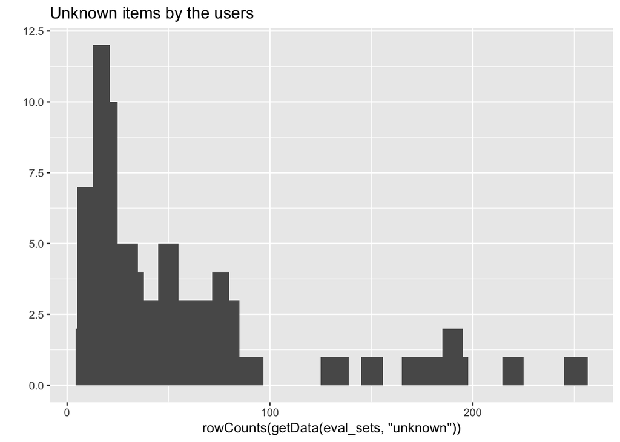

```r
qplot(rowCounts(getData(eval_sets, "unknown"))) +
  geom_histogram(binwidth = 10) +
  ggtitle("Unknown items by the users")
```

The above image displays the unknown items by the users, which varies a lot.

Using cross-validation to validate models

The k-fold cross-validation approach is the most accurate one, although it’s computationally heavier.

Using this approach, we split the data into some chunks, take a chunk out as the test set, and evaluate the accuracy. Then, we can do the same with each other chunk and compute the average accuracy.

```r
#using K= 4-fold
eval_sets <- evaluationScheme(data = ratings_movies,
                              method = "cross-validation",
                              k = 4,
                              given = movies_to_keep,
                              goodRating = rating_threshold)
size_sets <- sapply(eval_sets@runsTrain, length)
size_sets
```

```
## [1] 174 174 174 174
```

Using 4-fold approach, we get four sets of the same size 174.

Evavluating the ratings

First, re-define the evaluation sets, build IBCF model and create a matrix with predicted ratings.

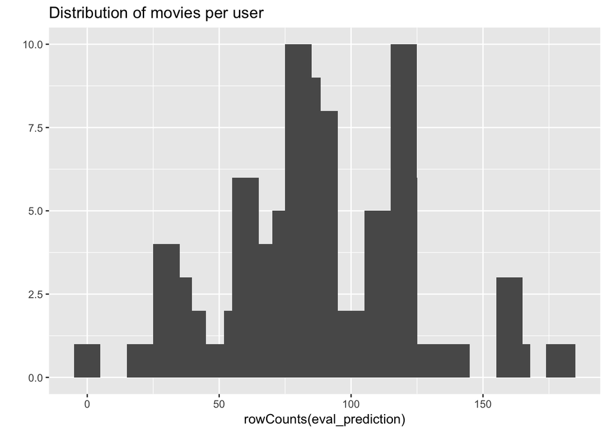

```r
eval_sets <- evaluationScheme(data = ratings_movies,
                              method = "cross-validation",
                              k = 4,
                              given = movies_to_keep,
                              goodRating = rating_threshold)


model_parameters <- NULL

eval_recommender <- Recommender(data = getData(eval_sets, "train"),
                                method = "IBCF",
                                parameter = model_parameters)

items_to_recommend <- 10
eval_prediction <- predict(object = eval_recommender,
                           newdata = getData(eval_sets, "known"),
                           n = items_to_recommend,
                           type = "ratings")

qplot(rowCounts(eval_prediction)) +
  geom_histogram(binwidth = 10) +
  ggtitle("Distribution of movies per user")
```

The image displays the distribution of movies per user in the matrix of predicted ratings.

Compute the accuracy measures for each user. Most of the RMSEs (Root mean square errors) are in the range of 0.5 to 1.8:

```r
eval_accuracy <- calcPredictionAccuracy(x = eval_prediction,
                                        data = getData(eval_sets, "unknown"),
                                        byUser = TRUE)
head(eval_accuracy)
```

```
##           RMSE       MSE       MAE
## [1,] 0.7071068 0.5000000 0.5000000
## [2,] 1.5679073 2.4583333 1.2500000
## [3,] 1.6583124 2.7500000 1.5000000
## [4,] 2.1297512 4.5358401 1.5059615
## [5,] 0.6674068 0.4454318 0.5979203
## [6,] 1.2554387 1.5761263 1.2335279
```

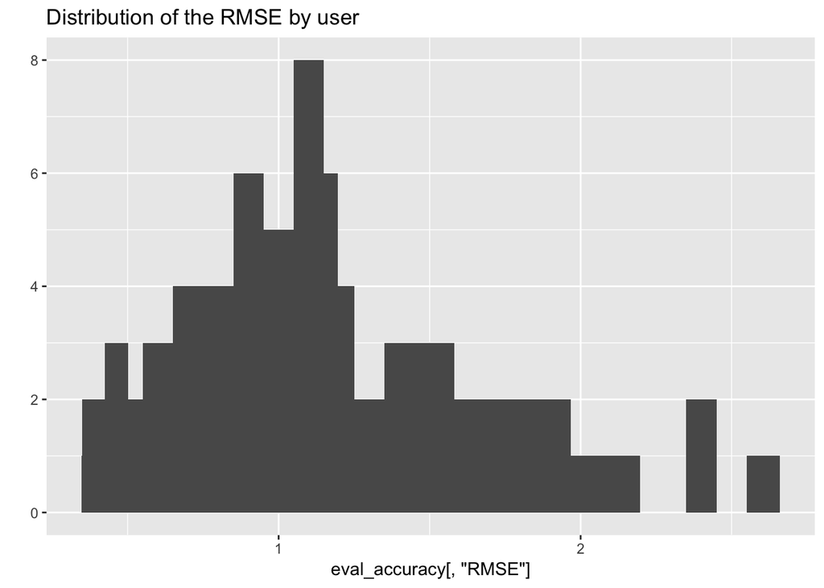

```r
qplot(eval_accuracy[, "RMSE"]) +
  geom_histogram(binwidth = 0.1) +
  ggtitle("Distribution of the RMSE by user")
```

Evaluating the recommendations

```r
results <- evaluate(x = eval_sets,
                    method = "IBCF",
                    n = seq(5, 20, 2))
```

```
## IBCF run fold/sample [model time/prediction time]
##   1  [0.235sec/0.019sec]
##   2  [0.218sec/0.018sec]
##   3  [0.214sec/0.019sec]
##   4  [0.217sec/0.019sec]
```

```r
head(getConfusionMatrix(results)[[1]])
```

```
##           TP        FP       FN       TN precision     recall        TPR
## 5  0.6833333  4.233333 42.66667 228.4167 0.1389831 0.01901695 0.01901695
## 7  1.0833333  5.800000 42.26667 226.8500 0.1573850 0.02811434 0.02811434
## 9  1.4000000  7.450000 41.95000 225.2000 0.1581921 0.03441378 0.03441378
## 11 1.6333333  9.183333 41.71667 223.4667 0.1510015 0.03981554 0.03981554
## 13 1.9333333 10.850000 41.41667 221.8000 0.1512386 0.04775950 0.04775950
## 15 2.2333333 12.516667 41.11667 220.1333 0.1514124 0.05583552 0.05583552
##           FPR
## 5  0.01829441
## 7  0.02519742
## 9  0.03220616
## 11 0.03961394
## 13 0.04676513
## 15 0.05405513
```

```r
results1 <- evaluate(x = eval_sets,
                    method = "UBCF",
                    n = seq(5, 20, 2))
```

```
## UBCF run fold/sample [model time/prediction time]
##   1  [0.003sec/0.069sec]
##   2  [0.002sec/0.052sec]
##   3  [0.002sec/0.064sec]
##   4  [0.002sec/0.054sec]
```

Plot the ROC and the precision/recall curves:

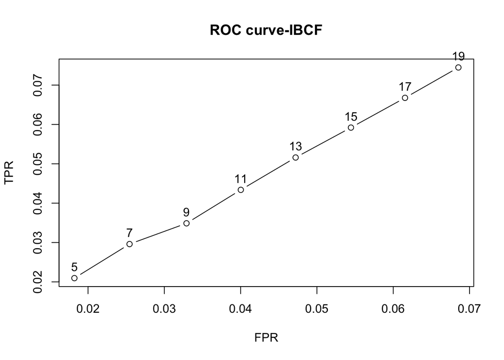

```r
#IBCF
plot(results, annotate = TRUE, main = "ROC curve-IBCF")
```

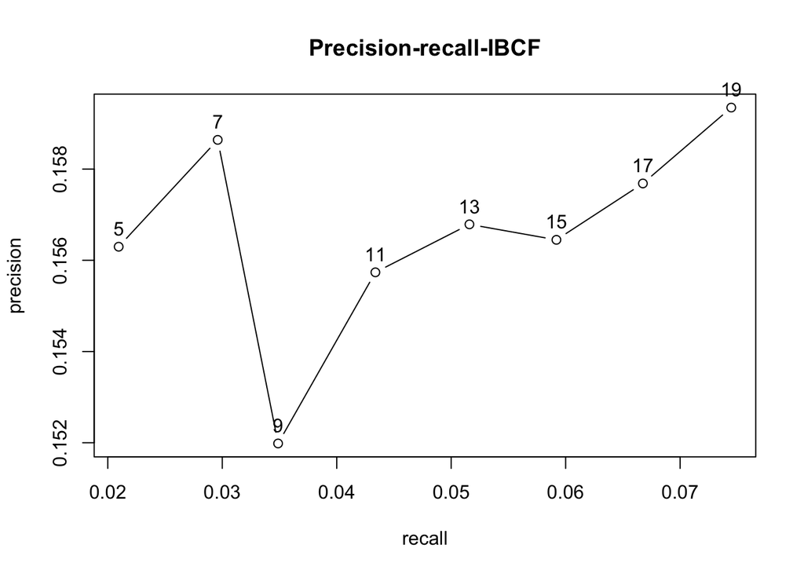

```r
plot(results, "prec/rec", annotate = TRUE, main = "Precision-recall-IBCF")
```

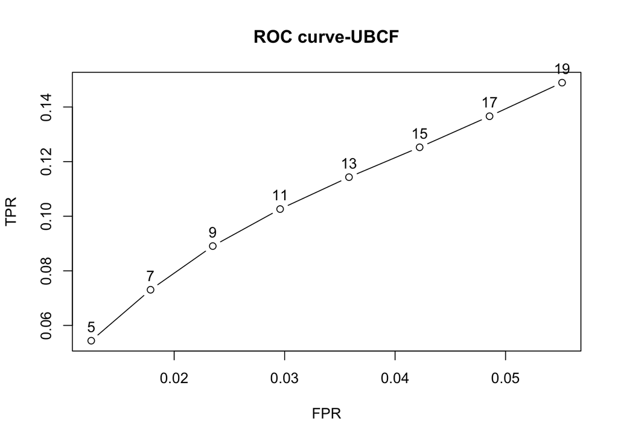

```r
#UBCF
plot(results1, annotate = TRUE, main = "ROC curve-UBCF")
```

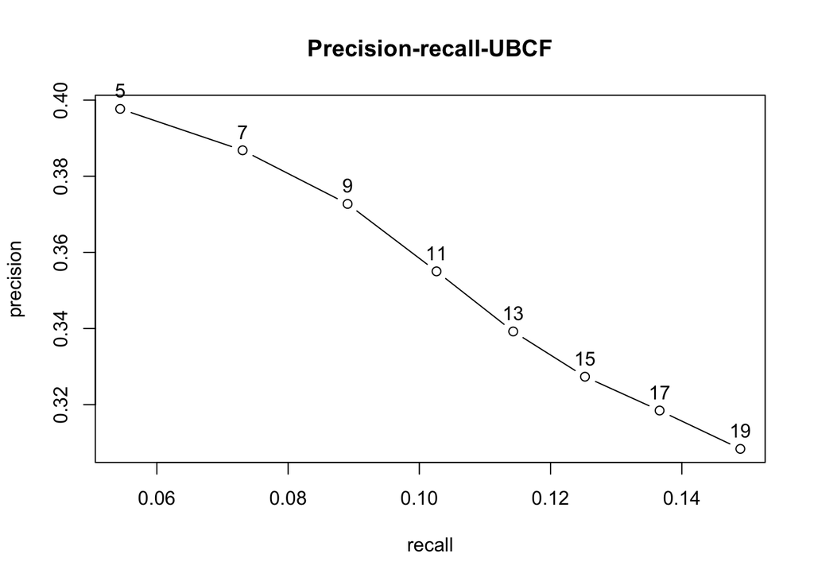

```r
plot(results1, "prec/rec", annotate = TRUE, main = "Precision-recall-UBCF")
```